# Part 5: Structure of a project

Lars Vilhuber

Marie Connolly

2024-05-14

## The Plan

| - 13:00 Bienvenue |  |
| --- | --- |
| - 13:15 Description de l’agenda pour les deux jours |  |
| - 13:30 Discussion sur les pré-requis techniques, possiblement formation d’équipes |  |
| - 13:45 [Day One](https://thnk.ng/day1/) |  |
| - 15:30 Description de l’exemple très imparfait |  |

## Overview

- **Reproducible practices**
- Ideal directory and data structure
- Some programming practices

# Part 1 | Ideal structure

## Generic project setup

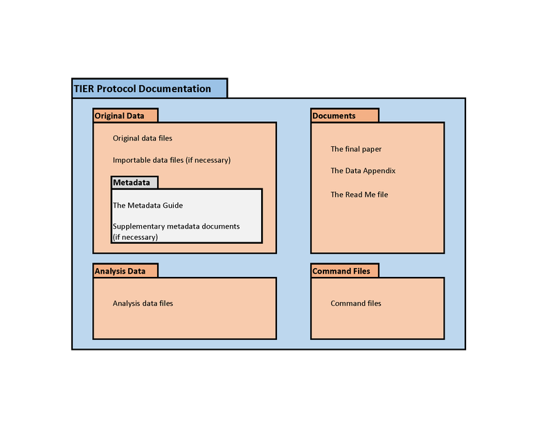

[TIER Protocol](https://www.projecttier.org/tier-protocol/specifications-3-0/)

## Basic project setup

**Structure your project**

- Data inputs
- Data outputs
- Code
- Paper/text/etc.

**Version your project (`git`)!**

**Track metadata**

- cite articles you reference
- *cite* data sources you use
  - We will get back to data citations later!

## Project setup examples

```
/inputs
/outputs
/code
/paper
```

```
/datos/
    /brutos
    /limpiados
    /finales
/codigo
/articulo
```

It doesn’t really matter, as long as it is logical. We will get to how this translates to confidential or big data in a moment!

# Computational Empathy

## Consider how the next person will (be able to) compute

- You don’t know who that is
- You don’t know what they don’t know
- Will not have any of your add-on packages/ libraries/ etc. pre-installed
- Don’t force them to do tedious things

**It might be “Future You!”**

## Streamlining

- Master script preferred
  - Least amount of manual effort
- No manual copying of results
  - (dynamic documents!)
  - Write out/save tables and figures using packages
- Clear instructions
- No manual install of packages
  - Use a script to create all directories, install all necessary packages/requirements/etc.

## Reproducibility

- No manual manipulation
  - “Change the parameter to 0.2, then run the code again”
  - Use *functions*, ado files, programs, macros, subroutines
  - Use *loops*, parameters, *parameter files* to call those subroutines
  - Use *placeholders* (globals, macros, libnames, etc.) for common locations ($CONFDATA, $TABLES, $CODE)
- Compute all numbers in package
  - No manual calculation of numbers
- Use cross-platform programming practices

## Cross-platform programming practices 1

**Use programming-language specific code as much as possible**

Avoid

```r
system("unzip C:\data\myfile.zip")
```

or

```stata
shell unzip "C:\data\myfile.zip"
```

## Cross-platform programming practices 1

Most languages have appropriate code:

R:

```r
unzip(zipfile, files = NULL, list = FALSE, overwrite = TRUE,
      junkpaths = FALSE, exdir = ".", unzip = "internal",
      setTimes = FALSE)
```

Stata:

```stata
unzipfile "zipfile.zip" [, replace]
```

## Cross-platform programming practices 2

Use neutral pathnames (mostly forward slashes)

**R**: Use functions to combine paths (and/or use forward slashes), packages to make code more portable.

```
basepath <- rprojroot::find_root(rprojroot::has_file("README.md"))
data <- read.dta(file.path(basepath,"path","data.dta"))
```

**Stata**: *always* use forward slashes, even on Windows

```
global data "/my/computer"
use "$data/path/data.dta"
```

# More complex Data structures

## Back to the TIER protocol

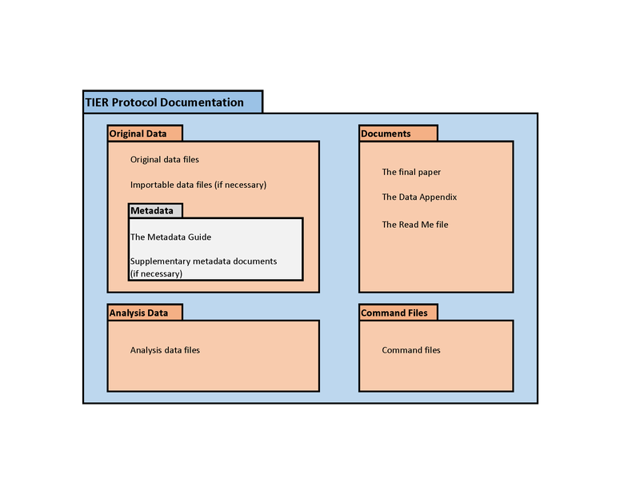

## Generic suggested data structure

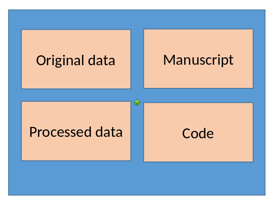

## When data are big/in the cloud

[figure not shown]

## When data are confidential

[figure not shown]

## When data are confidential

[figure not shown]

## Project setup examples

This may no longer work:

```
/data/
    /raw
    /clean
    /final
/code
/article
```

But this might

```
/project123/
     /data/
        /raw
        /clean
        /final
     /code
     /article
/confidential        (read-only)
     /taxes          (read-only)
     /wages          (read-only)
```

## Stata configuration files

File structure thus becomes more complex, but fundamentally not so different:

```stata
global taxdata    "/confidential/taxes"
global salarydata "/confidential/wages"
global outputdata "/project/data/clean" // this is where you would write the data you create in this project
global results    "/project/article"    // All tables for inclusion in your paper go here
global programs   "/project/code"       // All programs (which you might "include") are to be found here
```

## Stata configuration files

Or even more robust:

```stata
global basedir     "/project123"
global confbase    "/data/provided"
global project     "$basedir/project"

global taxdata    "$confbase/taxes"
global salarydata "$confbase/wages"
global outputdata "$project/data/clean" // this is where you would write the data you create in this project
global results    "$project/article"    // All tables for inclusion in your paper go here
global programs   "$project/code"       // All programs (which you might "include") are to be found here
```

# Try it out!

- Set up a directory structure
- Set up a simple project
- Share it with us!

# Tomorrow

## The Plan

- 9:00 Discussion de la réussite de l’exercice “Very imperfect example”
- 9:30 Documenting it all: the template README
- 10:00 How to run Stata
- 10:30 Extra: How to install Stata packages
- 10:45 Break
- 11:00 Data provenance
- 12:00 Break
- 13:00 🔒[When data cleaning is critical](https://github.com/labordynamicsinstitute/very-imperfect-example-lesson/)
- 13:30 Improving the replication package (very imperfect -> a lot better)
- 14:00 Depositing a replication package
- 14:45 Testing it all
- 15:15 Wrap up
- 16:00 Fin.